# Risk Factor Analysis

## Outcome Variable

**Outcome Variable:** y_rate_len

## Predictor Variables

**Intervention Variable:** cleanck

**Adjustment Set:**

- arm
- sex
- W_mage
- meducyrs
- feducyrs
- hhwealth_quart
- W_nrooms
- W_nhh
- W_nchldlt5
- trth2o
- impfloor
- delta_meducyrs
- delta_feducyrs
- delta_hhwealth_quart
- delta_W_nrooms
- delta_W_nhh
- delta_W_nchldlt5
- delta_trth2o
- delta_impfloor

## Stratifying Variables

The analysis was stratified on these variable(s):

- agecat
- studyid
- country

## Data Summary

| agecat | studyid | country | cleanck | n_cell | n |
| --- | --- | --- | --- | --- | --- |
| 0-3 months | CMC-V-BCS-2002 | INDIA | 1 | 40 | 88 |
| 0-3 months | CMC-V-BCS-2002 | INDIA | 0 | 48 | 88 |
| 0-3 months | GMS-Nepal | NEPAL | 1 | 6 | 460 |
| 0-3 months | GMS-Nepal | NEPAL | 0 | 454 | 460 |
| 0-3 months | IRC | INDIA | 1 | 212 | 369 |
| 0-3 months | IRC | INDIA | 0 | 157 | 369 |
| 0-3 months | MAL-ED | PERU | 1 | 1 | 1 |
| 0-3 months | MAL-ED | PERU | 0 | 0 | 1 |
| 0-3 months | MAL-ED | SOUTH AFRICA | 1 | 1 | 2 |
| 0-3 months | MAL-ED | SOUTH AFRICA | 0 | 1 | 2 |
| 0-3 months | NIH-Crypto | BANGLADESH | 1 | 334 | 547 |
| 0-3 months | NIH-Crypto | BANGLADESH | 0 | 213 | 547 |
| 0-3 months | PROVIDE | BANGLADESH | 1 | 529 | 640 |
| 0-3 months | PROVIDE | BANGLADESH | 0 | 111 | 640 |
| 3-6 months | CMC-V-BCS-2002 | INDIA | 1 | 133 | 307 |
| 3-6 months | CMC-V-BCS-2002 | INDIA | 0 | 174 | 307 |
| 3-6 months | GMS-Nepal | NEPAL | 1 | 6 | 424 |
| 3-6 months | GMS-Nepal | NEPAL | 0 | 418 | 424 |
| 3-6 months | IRC | INDIA | 1 | 224 | 390 |
| 3-6 months | IRC | INDIA | 0 | 166 | 390 |
| 3-6 months | MAL-ED | SOUTH AFRICA | 1 | 1 | 1 |
| 3-6 months | MAL-ED | SOUTH AFRICA | 0 | 0 | 1 |
| 3-6 months | NIH-Crypto | BANGLADESH | 1 | 315 | 527 |
| 3-6 months | NIH-Crypto | BANGLADESH | 0 | 212 | 527 |
| 3-6 months | PROVIDE | BANGLADESH | 1 | 492 | 598 |
| 3-6 months | PROVIDE | BANGLADESH | 0 | 106 | 598 |
| 6-9 months | CMC-V-BCS-2002 | INDIA | 1 | 136 | 313 |
| 6-9 months | CMC-V-BCS-2002 | INDIA | 0 | 177 | 313 |
| 6-9 months | GMS-Nepal | NEPAL | 1 | 8 | 433 |
| 6-9 months | GMS-Nepal | NEPAL | 0 | 425 | 433 |

[output cut: 68 more lines]

The following strata were considered:

- agecat: 0-3 months, studyid: CMC-V-BCS-2002, country: INDIA
- agecat: 0-3 months, studyid: GMS-Nepal, country: NEPAL
- agecat: 0-3 months, studyid: IRC, country: INDIA
- agecat: 0-3 months, studyid: MAL-ED, country: PERU
- agecat: 0-3 months, studyid: MAL-ED, country: SOUTH AFRICA
- agecat: 0-3 months, studyid: NIH-Crypto, country: BANGLADESH
- agecat: 0-3 months, studyid: PROVIDE, country: BANGLADESH
- agecat: 12-15 months, studyid: CMC-V-BCS-2002, country: INDIA
- agecat: 12-15 months, studyid: GMS-Nepal, country: NEPAL
- agecat: 12-15 months, studyid: IRC, country: INDIA
- agecat: 12-15 months, studyid: MAL-ED, country: SOUTH AFRICA
- agecat: 12-15 months, studyid: NIH-Crypto, country: BANGLADESH
- agecat: 12-15 months, studyid: PROVIDE, country: BANGLADESH
- agecat: 15-18 months, studyid: CMC-V-BCS-2002, country: INDIA
- agecat: 15-18 months, studyid: GMS-Nepal, country: NEPAL
- agecat: 15-18 months, studyid: IRC, country: INDIA
- agecat: 15-18 months, studyid: MAL-ED, country: SOUTH AFRICA
- agecat: 15-18 months, studyid: NIH-Crypto, country: BANGLADESH
- agecat: 15-18 months, studyid: PROVIDE, country: BANGLADESH
- agecat: 18-21 months, studyid: CMC-V-BCS-2002, country: INDIA
- agecat: 18-21 months, studyid: GMS-Nepal, country: NEPAL
- agecat: 18-21 months, studyid: IRC, country: INDIA
- agecat: 18-21 months, studyid: MAL-ED, country: SOUTH AFRICA
- agecat: 18-21 months, studyid: NIH-Crypto, country: BANGLADESH
- agecat: 18-21 months, studyid: PROVIDE, country: BANGLADESH
- agecat: 21-24 months, studyid: CMC-V-BCS-2002, country: INDIA
- agecat: 21-24 months, studyid: GMS-Nepal, country: NEPAL
- agecat: 21-24 months, studyid: IRC, country: INDIA
- agecat: 21-24 months, studyid: MAL-ED, country: SOUTH AFRICA
- agecat: 21-24 months, studyid: NIH-Crypto, country: BANGLADESH
- agecat: 21-24 months, studyid: PROVIDE, country: BANGLADESH
- agecat: 3-6 months, studyid: CMC-V-BCS-2002, country: INDIA
- agecat: 3-6 months, studyid: GMS-Nepal, country: NEPAL
- agecat: 3-6 months, studyid: IRC, country: INDIA
- agecat: 3-6 months, studyid: MAL-ED, country: SOUTH AFRICA
- agecat: 3-6 months, studyid: NIH-Crypto, country: BANGLADESH
- agecat: 3-6 months, studyid: PROVIDE, country: BANGLADESH
- agecat: 6-9 months, studyid: CMC-V-BCS-2002, country: INDIA
- agecat: 6-9 months, studyid: GMS-Nepal, country: NEPAL
- agecat: 6-9 months, studyid: IRC, country: INDIA
- agecat: 6-9 months, studyid: MAL-ED, country: SOUTH AFRICA
- agecat: 6-9 months, studyid: NIH-Crypto, country: BANGLADESH
- agecat: 6-9 months, studyid: PROVIDE, country: BANGLADESH
- agecat: 9-12 months, studyid: CMC-V-BCS-2002, country: INDIA
- agecat: 9-12 months, studyid: GMS-Nepal, country: NEPAL
- agecat: 9-12 months, studyid: IRC, country: INDIA
- agecat: 9-12 months, studyid: MAL-ED, country: SOUTH AFRICA
- agecat: 9-12 months, studyid: NIH-Crypto, country: BANGLADESH
- agecat: 9-12 months, studyid: PROVIDE, country: BANGLADESH

### Dropped Strata

Some strata were dropped due to rare outcomes:

- agecat: 0-3 months, studyid: MAL-ED, country: PERU
- agecat: 0-3 months, studyid: MAL-ED, country: SOUTH AFRICA
- agecat: 3-6 months, studyid: MAL-ED, country: SOUTH AFRICA
- agecat: 6-9 months, studyid: MAL-ED, country: SOUTH AFRICA
- agecat: 9-12 months, studyid: MAL-ED, country: SOUTH AFRICA
- agecat: 12-15 months, studyid: MAL-ED, country: SOUTH AFRICA
- agecat: 15-18 months, studyid: MAL-ED, country: SOUTH AFRICA
- agecat: 18-21 months, studyid: MAL-ED, country: SOUTH AFRICA
- agecat: 21-24 months, studyid: GMS-Nepal, country: NEPAL
- agecat: 21-24 months, studyid: MAL-ED, country: SOUTH AFRICA

## Methods Detail

We’re interested in the causal parameters $E[Y_a]$ for all values of $a \in \mathcal{A}$. These parameters represent the mean outcome if, possibly contrary to fact, we intervened to set all units to have $A=a$. Under the randomization and positivity assumptions, these are identified by the statistical parameters $\psi_a=E_W[E_{Y|A,W}(Y|A=a,W)]$. In addition, we’re interested in the mean of $Y$, $E[Y]$ under no intervention (the observed mean). We will estimate these parameters by using SuperLearner to fit the relevant likelihood factors – $E_{Y|A,W}(Y|A=a,W)$ and $p(A=a|W)$, and then updating our likelihood fit using a joint TMLE.

For unadjusted analyses ($W=\{\}$), initial likelihoods were estimated using Lrnr_glm to estimate the simple $E(Y|A)$ and Lrnr_mean to estimate $p(A)$. For adjusted analyses, a small library containing Lrnr_glmnet, Lrnr_xgboost, and Lrnr_mean was used.

Having estimated these parameters, we will then use the delta method to estimate relative risks and attributable risks relative to a prespecified baseline level of $A$.

# Results Detail

## Results Plots

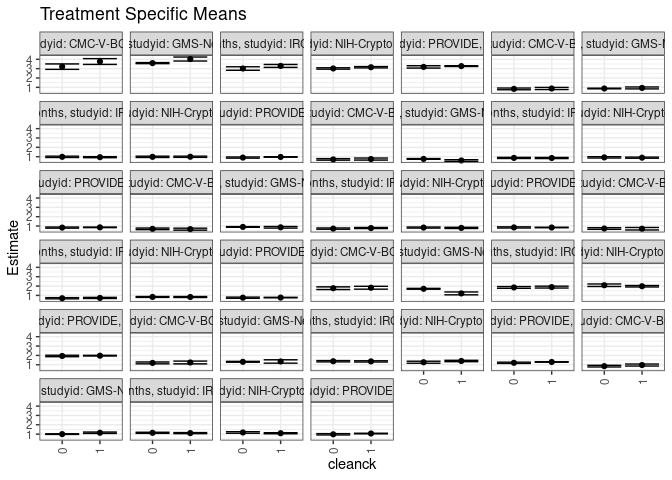

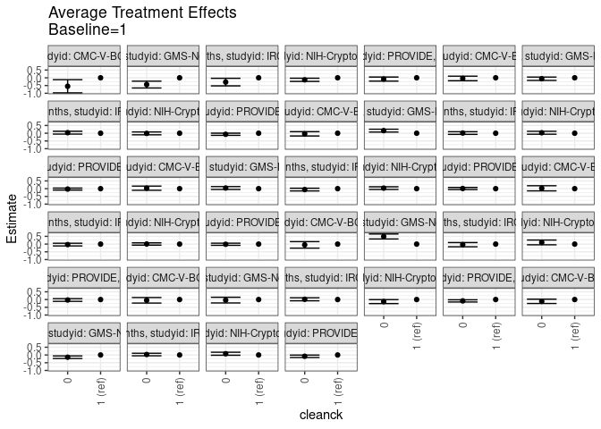

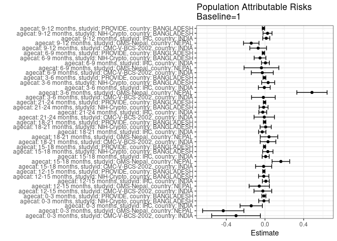

## Results Table

### Parameter: TSM

| agecat | studyid | country | intervention_level | baseline_level | estimate | ci_lower | ci_upper |
| --- | --- | --- | --- | --- | --- | --- | --- |
| 0-3 months | CMC-V-BCS-2002 | INDIA | 1 | NA | 3.7597571 | 3.4511692 | 4.0683451 |
| 0-3 months | CMC-V-BCS-2002 | INDIA | 0 | NA | 3.2112151 | 2.9204323 | 3.5019978 |
| 0-3 months | GMS-Nepal | NEPAL | 1 | NA | 4.0267398 | 3.8145010 | 4.2389786 |
| 0-3 months | GMS-Nepal | NEPAL | 0 | NA | 3.5890576 | 3.5338399 | 3.6442753 |
| 0-3 months | IRC | INDIA | 1 | NA | 3.2885614 | 3.1318918 | 3.4452310 |
| 0-3 months | IRC | INDIA | 0 | NA | 3.0118414 | 2.8248679 | 3.1988149 |
| 0-3 months | NIH-Crypto | BANGLADESH | 1 | NA | 3.1486270 | 3.0803447 | 3.2169093 |
| 0-3 months | NIH-Crypto | BANGLADESH | 0 | NA | 3.0180628 | 2.9433788 | 3.0927468 |
| 0-3 months | PROVIDE | BANGLADESH | 1 | NA | 3.2687204 | 3.2264967 | 3.3109440 |
| 0-3 months | PROVIDE | BANGLADESH | 0 | NA | 3.1853817 | 3.0599631 | 3.3108002 |
| 3-6 months | CMC-V-BCS-2002 | INDIA | 1 | NA | 1.8206878 | 1.6671967 | 1.9741790 |
| 3-6 months | CMC-V-BCS-2002 | INDIA | 0 | NA | 1.7704439 | 1.6282621 | 1.9126258 |
| 3-6 months | GMS-Nepal | NEPAL | 1 | NA | 1.2139650 | 1.0591458 | 1.3687842 |
| 3-6 months | GMS-Nepal | NEPAL | 0 | NA | 1.7068916 | 1.6642904 | 1.7494928 |
| 3-6 months | IRC | INDIA | 1 | NA | 1.8877753 | 1.7893688 | 1.9861817 |
| 3-6 months | IRC | INDIA | 0 | NA | 1.8515790 | 1.7593205 | 1.9438376 |
| 3-6 months | NIH-Crypto | BANGLADESH | 1 | NA | 1.9799416 | 1.9050183 | 2.0548650 |
| 3-6 months | NIH-Crypto | BANGLADESH | 0 | NA | 2.0896414 | 1.9551754 | 2.2241073 |
| 3-6 months | PROVIDE | BANGLADESH | 1 | NA | 1.9714753 | 1.9325492 | 2.0104015 |
| 3-6 months | PROVIDE | BANGLADESH | 0 | NA | 1.9408391 | 1.8643604 | 2.0173178 |
| 6-9 months | CMC-V-BCS-2002 | INDIA | 1 | NA | 1.2452067 | 1.0967370 | 1.3936763 |
| 6-9 months | CMC-V-BCS-2002 | INDIA | 0 | NA | 1.1965284 | 1.0972804 | 1.2957765 |
| 6-9 months | GMS-Nepal | NEPAL | 1 | NA | 1.3515781 | 1.1725495 | 1.5306067 |
| 6-9 months | GMS-Nepal | NEPAL | 0 | NA | 1.3140376 | 1.2691138 | 1.3589614 |
| 6-9 months | IRC | INDIA | 1 | NA | 1.3609263 | 1.2946638 | 1.4271889 |
| 6-9 months | IRC | INDIA | 0 | NA | 1.3765655 | 1.3056927 | 1.4474382 |
| 6-9 months | NIH-Crypto | BANGLADESH | 1 | NA | 1.4041426 | 1.3320349 | 1.4762502 |
| 6-9 months | NIH-Crypto | BANGLADESH | 0 | NA | 1.2712032 | 1.1659002 | 1.3765062 |
| 6-9 months | PROVIDE | BANGLADESH | 1 | NA | 1.2988546 | 1.2707408 | 1.3269684 |
| 6-9 months | PROVIDE | BANGLADESH | 0 | NA | 1.2104205 | 1.1450884 | 1.2757526 |
| 9-12 months | CMC-V-BCS-2002 | INDIA | 1 | NA | 0.9701025 | 0.8642345 | 1.0759706 |
| 9-12 months | CMC-V-BCS-2002 | INDIA | 0 | NA | 0.8541747 | 0.7635143 | 0.9448351 |
| 9-12 months | GMS-Nepal | NEPAL | 1 | NA | 1.1461261 | 1.0720811 | 1.2201711 |
| 9-12 months | GMS-Nepal | NEPAL | 0 | NA | 1.0011032 | 0.9653508 | 1.0368557 |
| 9-12 months | IRC | INDIA | 1 | NA | 1.1098601 | 1.0535185 | 1.1662018 |
| 9-12 months | IRC | INDIA | 0 | NA | 1.1392436 | 1.0793182 | 1.1991689 |
| 9-12 months | NIH-Crypto | BANGLADESH | 1 | NA | 1.0982074 | 1.0424780 | 1.1539368 |
| 9-12 months | NIH-Crypto | BANGLADESH | 0 | NA | 1.1780213 | 1.0977003 | 1.2583423 |
| 9-12 months | PROVIDE | BANGLADESH | 1 | NA | 1.0659188 | 1.0355916 | 1.0962459 |
| 9-12 months | PROVIDE | BANGLADESH | 0 | NA | 0.9815500 | 0.9106310 | 1.0524689 |
| 12-15 months | CMC-V-BCS-2002 | INDIA | 1 | NA | 0.8755870 | 0.7617755 | 0.9893986 |
| 12-15 months | CMC-V-BCS-2002 | INDIA | 0 | NA | 0.8324681 | 0.7393582 | 0.9255781 |
| 12-15 months | GMS-Nepal | NEPAL | 1 | NA | 0.9345104 | 0.8314399 | 1.0375809 |
| 12-15 months | GMS-Nepal | NEPAL | 0 | NA | 0.8742379 | 0.8427187 | 0.9057571 |
| 12-15 months | IRC | INDIA | 1 | NA | 0.9485722 | 0.8926209 | 1.0045235 |
| 12-15 months | IRC | INDIA | 0 | NA | 0.9844513 | 0.9131064 | 1.0557962 |
| 12-15 months | NIH-Crypto | BANGLADESH | 1 | NA | 0.9928269 | 0.9312863 | 1.0543675 |
| 12-15 months | NIH-Crypto | BANGLADESH | 0 | NA | 0.9831781 | 0.9144834 | 1.0518727 |
| 12-15 months | PROVIDE | BANGLADESH | 1 | NA | 0.9712361 | 0.9422522 | 1.0002199 |
| 12-15 months | PROVIDE | BANGLADESH | 0 | NA | 0.9040282 | 0.8397780 | 0.9682785 |
| 15-18 months | CMC-V-BCS-2002 | INDIA | 1 | NA | 0.7482633 | 0.6387123 | 0.8578143 |
| 15-18 months | CMC-V-BCS-2002 | INDIA | 0 | NA | 0.7092605 | 0.6297007 | 0.7888202 |
| 15-18 months | GMS-Nepal | NEPAL | 1 | NA | 0.5938125 | 0.5084972 | 0.6791279 |
| 15-18 months | GMS-Nepal | NEPAL | 0 | NA | 0.7611989 | 0.7229049 | 0.7994929 |
| 15-18 months | IRC | INDIA | 1 | NA | 0.8567375 | 0.7966939 | 0.9167811 |
| 15-18 months | IRC | INDIA | 0 | NA | 0.8686626 | 0.8089656 | 0.9283595 |
| 15-18 months | NIH-Crypto | BANGLADESH | 1 | NA | 0.8946778 | 0.8338978 | 0.9554577 |
| 15-18 months | NIH-Crypto | BANGLADESH | 0 | NA | 0.9255379 | 0.8546273 | 0.9964484 |
| 15-18 months | PROVIDE | BANGLADESH | 1 | NA | 0.8609707 | 0.8343341 | 0.8876072 |
| 15-18 months | PROVIDE | BANGLADESH | 0 | NA | 0.8344414 | 0.7766283 | 0.8922545 |
| 18-21 months | CMC-V-BCS-2002 | INDIA | 1 | NA | 0.6691096 | 0.5637761 | 0.7744431 |
| 18-21 months | CMC-V-BCS-2002 | INDIA | 0 | NA | 0.7002143 | 0.6164728 | 0.7839558 |
| 18-21 months | GMS-Nepal | NEPAL | 1 | NA | 0.8652948 | 0.7802558 | 0.9503338 |
| 18-21 months | GMS-Nepal | NEPAL | 0 | NA | 0.9075162 | 0.8701345 | 0.9448979 |
| 18-21 months | IRC | INDIA | 1 | NA | 0.7850693 | 0.7282631 | 0.8418756 |
| 18-21 months | IRC | INDIA | 0 | NA | 0.7259946 | 0.6596257 | 0.7923635 |
| 18-21 months | NIH-Crypto | BANGLADESH | 1 | NA | 0.8028543 | 0.7378446 | 0.8678639 |
| 18-21 months | NIH-Crypto | BANGLADESH | 0 | NA | 0.8378458 | 0.7827684 | 0.8929233 |
| 18-21 months | PROVIDE | BANGLADESH | 1 | NA | 0.8433991 | 0.8174119 | 0.8693863 |
| 18-21 months | PROVIDE | BANGLADESH | 0 | NA | 0.8533867 | 0.7895453 | 0.9172281 |
| 21-24 months | CMC-V-BCS-2002 | INDIA | 1 | NA | 0.7143127 | 0.5820183 | 0.8466072 |
| 21-24 months | CMC-V-BCS-2002 | INDIA | 0 | NA | 0.7374989 | 0.6539445 | 0.8210532 |
| 21-24 months | IRC | INDIA | 1 | NA | 0.7297546 | 0.6702859 | 0.7892232 |
| 21-24 months | IRC | INDIA | 0 | NA | 0.6982655 | 0.6358597 | 0.7606713 |
| 21-24 months | NIH-Crypto | BANGLADESH | 1 | NA | 0.8293577 | 0.7750558 | 0.8836597 |
| 21-24 months | NIH-Crypto | BANGLADESH | 0 | NA | 0.8358453 | 0.7875571 | 0.8841334 |
| 21-24 months | PROVIDE | BANGLADESH | 1 | NA | 0.7676677 | 0.7399351 | 0.7954003 |
| 21-24 months | PROVIDE | BANGLADESH | 0 | NA | 0.7570699 | 0.6937016 | 0.8204382 |

### Parameter: E(Y)

| agecat | studyid | country | intervention_level | baseline_level | estimate | ci_lower | ci_upper |
| --- | --- | --- | --- | --- | --- | --- | --- |
| 0-3 months | CMC-V-BCS-2002 | INDIA | NA | NA | 3.4601875 | 3.2440906 | 3.6762845 |
| 0-3 months | GMS-Nepal | NEPAL | NA | NA | 3.5947665 | 3.5404780 | 3.6490550 |
| 0-3 months | IRC | INDIA | NA | NA | 3.1459932 | 3.0340880 | 3.2578984 |
| 0-3 months | NIH-Crypto | BANGLADESH | NA | NA | 3.1373236 | 3.0972506 | 3.1773966 |
| 0-3 months | PROVIDE | BANGLADESH | NA | NA | 3.2576810 | 3.2206777 | 3.2946843 |
| 3-6 months | CMC-V-BCS-2002 | INDIA | NA | NA | 1.8037880 | 1.7029866 | 1.9045894 |
| 3-6 months | GMS-Nepal | NEPAL | NA | NA | 1.6999162 | 1.6578328 | 1.7419997 |
| 3-6 months | IRC | INDIA | NA | NA | 1.8807708 | 1.8161067 | 1.9454349 |
| 3-6 months | NIH-Crypto | BANGLADESH | NA | NA | 2.0125524 | 1.9699507 | 2.0551541 |
| 3-6 months | PROVIDE | BANGLADESH | NA | NA | 1.9657457 | 1.9318660 | 1.9996254 |
| 6-9 months | CMC-V-BCS-2002 | INDIA | NA | NA | 1.2173381 | 1.1398153 | 1.2948610 |
| 6-9 months | GMS-Nepal | NEPAL | NA | NA | 1.3147312 | 1.2706998 | 1.3587625 |
| 6-9 months | IRC | INDIA | NA | NA | 1.3656516 | 1.3178011 | 1.4135021 |
| 6-9 months | NIH-Crypto | BANGLADESH | NA | NA | 1.3527759 | 1.3181375 | 1.3874142 |
| 6-9 months | PROVIDE | BANGLADESH | NA | NA | 1.2824185 | 1.2571827 | 1.3076542 |
| 9-12 months | CMC-V-BCS-2002 | INDIA | NA | NA | 0.8995224 | 0.8316661 | 0.9673787 |
| 9-12 months | GMS-Nepal | NEPAL | NA | NA | 1.0038395 | 0.9688811 | 1.0387978 |
| 9-12 months | IRC | INDIA | NA | NA | 1.1229343 | 1.0831083 | 1.1627603 |
| 9-12 months | NIH-Crypto | BANGLADESH | NA | NA | 1.1243367 | 1.0942919 | 1.1543816 |
| 9-12 months | PROVIDE | BANGLADESH | NA | NA | 1.0499750 | 1.0230130 | 1.0769370 |
| 12-15 months | CMC-V-BCS-2002 | INDIA | NA | NA | 0.8533724 | 0.7837188 | 0.9230260 |
| 12-15 months | GMS-Nepal | NEPAL | NA | NA | 0.8753778 | 0.8445288 | 0.9062268 |
| 12-15 months | IRC | INDIA | NA | NA | 0.9574323 | 0.9150475 | 0.9998172 |
| 12-15 months | NIH-Crypto | BANGLADESH | NA | NA | 0.9797232 | 0.9513105 | 1.0081359 |
| 12-15 months | PROVIDE | BANGLADESH | NA | NA | 0.9597501 | 0.9335899 | 0.9859102 |
| 15-18 months | CMC-V-BCS-2002 | INDIA | NA | NA | 0.7339135 | 0.6710399 | 0.7967871 |
| 15-18 months | GMS-Nepal | NEPAL | NA | NA | 0.7581134 | 0.7206558 | 0.7955710 |
| 15-18 months | IRC | INDIA | NA | NA | 0.8635602 | 0.8235728 | 0.9035477 |
| 15-18 months | NIH-Crypto | BANGLADESH | NA | NA | 0.9239169 | 0.8976277 | 0.9502061 |
| 15-18 months | PROVIDE | BANGLADESH | NA | NA | 0.8560998 | 0.8320145 | 0.8801852 |
| 18-21 months | CMC-V-BCS-2002 | INDIA | NA | NA | 0.6999920 | 0.6362204 | 0.7637635 |
| 18-21 months | GMS-Nepal | NEPAL | NA | NA | 0.9067882 | 0.8702752 | 0.9433012 |
| 18-21 months | IRC | INDIA | NA | NA | 0.7567726 | 0.7181843 | 0.7953609 |
| 18-21 months | NIH-Crypto | BANGLADESH | NA | NA | 0.8098412 | 0.7838581 | 0.8358244 |
| 18-21 months | PROVIDE | BANGLADESH | NA | NA | 0.8393377 | 0.8153485 | 0.8633269 |
| 21-24 months | CMC-V-BCS-2002 | INDIA | NA | NA | 0.7068472 | 0.6454809 | 0.7682134 |
| 21-24 months | IRC | INDIA | NA | NA | 0.7066493 | 0.6649098 | 0.7483888 |
| 21-24 months | NIH-Crypto | BANGLADESH | NA | NA | 0.8147508 | 0.7880257 | 0.8414758 |
| 21-24 months | PROVIDE | BANGLADESH | NA | NA | 0.7631391 | 0.7377453 | 0.7885328 |

### Parameter: ATE

| agecat | studyid | country | intervention_level | baseline_level | estimate | ci_lower | ci_upper |
| --- | --- | --- | --- | --- | --- | --- | --- |
| 0-3 months | CMC-V-BCS-2002 | INDIA | 1 | 1 | 0.0000000 | 0.0000000 | 0.0000000 |
| 0-3 months | CMC-V-BCS-2002 | INDIA | 0 | 1 | -0.5485421 | -0.9751004 | -0.1219837 |
| 0-3 months | GMS-Nepal | NEPAL | 1 | 1 | 0.0000000 | 0.0000000 | 0.0000000 |
| 0-3 months | GMS-Nepal | NEPAL | 0 | 1 | -0.4376822 | -0.6569863 | -0.2183781 |
| 0-3 months | IRC | INDIA | 1 | 1 | 0.0000000 | 0.0000000 | 0.0000000 |
| 0-3 months | IRC | INDIA | 0 | 1 | -0.2767200 | -0.5217180 | -0.0317219 |
| 0-3 months | NIH-Crypto | BANGLADESH | 1 | 1 | 0.0000000 | 0.0000000 | 0.0000000 |
| 0-3 months | NIH-Crypto | BANGLADESH | 0 | 1 | -0.1305642 | -0.2324525 | -0.0286759 |
| 0-3 months | PROVIDE | BANGLADESH | 1 | 1 | 0.0000000 | 0.0000000 | 0.0000000 |
| 0-3 months | PROVIDE | BANGLADESH | 0 | 1 | -0.0833387 | -0.2157058 | 0.0490284 |
| 3-6 months | CMC-V-BCS-2002 | INDIA | 1 | 1 | 0.0000000 | 0.0000000 | 0.0000000 |
| 3-6 months | CMC-V-BCS-2002 | INDIA | 0 | 1 | -0.0502439 | -0.2598050 | 0.1593172 |
| 3-6 months | GMS-Nepal | NEPAL | 1 | 1 | 0.0000000 | 0.0000000 | 0.0000000 |
| 3-6 months | GMS-Nepal | NEPAL | 0 | 1 | 0.4929266 | 0.3323531 | 0.6535001 |
| 3-6 months | IRC | INDIA | 1 | 1 | 0.0000000 | 0.0000000 | 0.0000000 |
| 3-6 months | IRC | INDIA | 0 | 1 | -0.0361962 | -0.1717581 | 0.0993657 |
| 3-6 months | NIH-Crypto | BANGLADESH | 1 | 1 | 0.0000000 | 0.0000000 | 0.0000000 |
| 3-6 months | NIH-Crypto | BANGLADESH | 0 | 1 | 0.1096997 | -0.0443422 | 0.2637416 |
| 3-6 months | PROVIDE | BANGLADESH | 1 | 1 | 0.0000000 | 0.0000000 | 0.0000000 |
| 3-6 months | PROVIDE | BANGLADESH | 0 | 1 | -0.0306363 | -0.1165020 | 0.0552295 |
| 6-9 months | CMC-V-BCS-2002 | INDIA | 1 | 1 | 0.0000000 | 0.0000000 | 0.0000000 |
| 6-9 months | CMC-V-BCS-2002 | INDIA | 0 | 1 | -0.0486782 | -0.2274409 | 0.1300845 |
| 6-9 months | GMS-Nepal | NEPAL | 1 | 1 | 0.0000000 | 0.0000000 | 0.0000000 |
| 6-9 months | GMS-Nepal | NEPAL | 0 | 1 | -0.0375405 | -0.2221194 | 0.1470385 |
| 6-9 months | IRC | INDIA | 1 | 1 | 0.0000000 | 0.0000000 | 0.0000000 |
| 6-9 months | IRC | INDIA | 0 | 1 | 0.0156391 | -0.0818913 | 0.1131696 |
| 6-9 months | NIH-Crypto | BANGLADESH | 1 | 1 | 0.0000000 | 0.0000000 | 0.0000000 |
| 6-9 months | NIH-Crypto | BANGLADESH | 0 | 1 | -0.1329394 | -0.2610378 | -0.0048409 |
| 6-9 months | PROVIDE | BANGLADESH | 1 | 1 | 0.0000000 | 0.0000000 | 0.0000000 |
| 6-9 months | PROVIDE | BANGLADESH | 0 | 1 | -0.0884341 | -0.1595141 | -0.0173540 |
| 9-12 months | CMC-V-BCS-2002 | INDIA | 1 | 1 | 0.0000000 | 0.0000000 | 0.0000000 |
| 9-12 months | CMC-V-BCS-2002 | INDIA | 0 | 1 | -0.1159278 | -0.2559688 | 0.0241131 |
| 9-12 months | GMS-Nepal | NEPAL | 1 | 1 | 0.0000000 | 0.0000000 | 0.0000000 |
| 9-12 months | GMS-Nepal | NEPAL | 0 | 1 | -0.1450229 | -0.2272476 | -0.0627982 |
| 9-12 months | IRC | INDIA | 1 | 1 | 0.0000000 | 0.0000000 | 0.0000000 |
| 9-12 months | IRC | INDIA | 0 | 1 | 0.0293834 | -0.0531556 | 0.1119224 |
| 9-12 months | NIH-Crypto | BANGLADESH | 1 | 1 | 0.0000000 | 0.0000000 | 0.0000000 |
| 9-12 months | NIH-Crypto | BANGLADESH | 0 | 1 | 0.0798139 | -0.0178716 | 0.1774993 |
| 9-12 months | PROVIDE | BANGLADESH | 1 | 1 | 0.0000000 | 0.0000000 | 0.0000000 |
| 9-12 months | PROVIDE | BANGLADESH | 0 | 1 | -0.0843688 | -0.1617056 | -0.0070320 |
| 12-15 months | CMC-V-BCS-2002 | INDIA | 1 | 1 | 0.0000000 | 0.0000000 | 0.0000000 |
| 12-15 months | CMC-V-BCS-2002 | INDIA | 0 | 1 | -0.0431189 | -0.1901284 | 0.1038906 |
| 12-15 months | GMS-Nepal | NEPAL | 1 | 1 | 0.0000000 | 0.0000000 | 0.0000000 |
| 12-15 months | GMS-Nepal | NEPAL | 0 | 1 | -0.0602725 | -0.1680547 | 0.0475096 |
| 12-15 months | IRC | INDIA | 1 | 1 | 0.0000000 | 0.0000000 | 0.0000000 |
| 12-15 months | IRC | INDIA | 0 | 1 | 0.0358791 | -0.0548438 | 0.1266019 |
| 12-15 months | NIH-Crypto | BANGLADESH | 1 | 1 | 0.0000000 | 0.0000000 | 0.0000000 |
| 12-15 months | NIH-Crypto | BANGLADESH | 0 | 1 | -0.0096488 | -0.1019799 | 0.0826823 |
| 12-15 months | PROVIDE | BANGLADESH | 1 | 1 | 0.0000000 | 0.0000000 | 0.0000000 |
| 12-15 months | PROVIDE | BANGLADESH | 0 | 1 | -0.0672079 | -0.1376164 | 0.0032007 |
| 15-18 months | CMC-V-BCS-2002 | INDIA | 1 | 1 | 0.0000000 | 0.0000000 | 0.0000000 |
| 15-18 months | CMC-V-BCS-2002 | INDIA | 0 | 1 | -0.0390028 | -0.1776950 | 0.0996893 |
| 15-18 months | GMS-Nepal | NEPAL | 1 | 1 | 0.0000000 | 0.0000000 | 0.0000000 |
| 15-18 months | GMS-Nepal | NEPAL | 0 | 1 | 0.1673863 | 0.0738709 | 0.2609018 |
| 15-18 months | IRC | INDIA | 1 | 1 | 0.0000000 | 0.0000000 | 0.0000000 |
| 15-18 months | IRC | INDIA | 0 | 1 | 0.0119250 | -0.0733453 | 0.0971953 |
| 15-18 months | NIH-Crypto | BANGLADESH | 1 | 1 | 0.0000000 | 0.0000000 | 0.0000000 |
| 15-18 months | NIH-Crypto | BANGLADESH | 0 | 1 | 0.0308601 | -0.0627084 | 0.1244287 |
| 15-18 months | PROVIDE | BANGLADESH | 1 | 1 | 0.0000000 | 0.0000000 | 0.0000000 |
| 15-18 months | PROVIDE | BANGLADESH | 0 | 1 | -0.0265292 | -0.0903558 | 0.0372973 |
| 18-21 months | CMC-V-BCS-2002 | INDIA | 1 | 1 | 0.0000000 | 0.0000000 | 0.0000000 |
| 18-21 months | CMC-V-BCS-2002 | INDIA | 0 | 1 | 0.0311047 | -0.1035519 | 0.1657612 |
| 18-21 months | GMS-Nepal | NEPAL | 1 | 1 | 0.0000000 | 0.0000000 | 0.0000000 |
| 18-21 months | GMS-Nepal | NEPAL | 0 | 1 | 0.0422214 | -0.0506711 | 0.1351139 |
| 18-21 months | IRC | INDIA | 1 | 1 | 0.0000000 | 0.0000000 | 0.0000000 |
| 18-21 months | IRC | INDIA | 0 | 1 | -0.0590748 | -0.1469703 | 0.0288208 |
| 18-21 months | NIH-Crypto | BANGLADESH | 1 | 1 | 0.0000000 | 0.0000000 | 0.0000000 |
| 18-21 months | NIH-Crypto | BANGLADESH | 0 | 1 | 0.0349915 | -0.0503006 | 0.1202837 |
| 18-21 months | PROVIDE | BANGLADESH | 1 | 1 | 0.0000000 | 0.0000000 | 0.0000000 |
| 18-21 months | PROVIDE | BANGLADESH | 0 | 1 | 0.0099876 | -0.0589754 | 0.0789506 |
| 21-24 months | CMC-V-BCS-2002 | INDIA | 1 | 1 | 0.0000000 | 0.0000000 | 0.0000000 |
| 21-24 months | CMC-V-BCS-2002 | INDIA | 0 | 1 | 0.0231861 | -0.1424616 | 0.1888339 |
| 21-24 months | IRC | INDIA | 1 | 1 | 0.0000000 | 0.0000000 | 0.0000000 |
| 21-24 months | IRC | INDIA | 0 | 1 | -0.0314891 | -0.1180799 | 0.0551017 |
| 21-24 months | NIH-Crypto | BANGLADESH | 1 | 1 | 0.0000000 | 0.0000000 | 0.0000000 |
| 21-24 months | NIH-Crypto | BANGLADESH | 0 | 1 | 0.0064875 | -0.0663705 | 0.0793455 |
| 21-24 months | PROVIDE | BANGLADESH | 1 | 1 | 0.0000000 | 0.0000000 | 0.0000000 |
| 21-24 months | PROVIDE | BANGLADESH | 0 | 1 | -0.0105978 | -0.0797873 | 0.0585917 |

### Parameter: PAR

| agecat | studyid | country | intervention_level | baseline_level | estimate | ci_lower | ci_upper |
| --- | --- | --- | --- | --- | --- | --- | --- |
| 0-3 months | CMC-V-BCS-2002 | INDIA | 1 | NA | -0.2995696 | -0.5517532 | -0.0473860 |
| 0-3 months | GMS-Nepal | NEPAL | 1 | NA | -0.4319733 | -0.6458430 | -0.2181035 |
| 0-3 months | IRC | INDIA | 1 | NA | -0.1425682 | -0.2582745 | -0.0268618 |
| 0-3 months | NIH-Crypto | BANGLADESH | 1 | NA | -0.0113034 | -0.0650666 | 0.0424598 |
| 0-3 months | PROVIDE | BANGLADESH | 1 | NA | -0.0110393 | -0.0319779 | 0.0098992 |
| 3-6 months | CMC-V-BCS-2002 | INDIA | 1 | NA | -0.0168998 | -0.1395073 | 0.1057077 |
| 3-6 months | GMS-Nepal | NEPAL | 1 | NA | 0.4859512 | 0.3292938 | 0.6426086 |
| 3-6 months | IRC | INDIA | 1 | NA | -0.0070044 | -0.0678546 | 0.0538458 |
| 3-6 months | NIH-Crypto | BANGLADESH | 1 | NA | 0.0326108 | -0.0347267 | 0.0999484 |
| 3-6 months | PROVIDE | BANGLADESH | 1 | NA | -0.0057296 | -0.0204725 | 0.0090133 |
| 6-9 months | CMC-V-BCS-2002 | INDIA | 1 | NA | -0.0278685 | -0.1416236 | 0.0858866 |
| 6-9 months | GMS-Nepal | NEPAL | 1 | NA | -0.0368469 | -0.2168120 | 0.1431182 |
| 6-9 months | IRC | INDIA | 1 | NA | 0.0047252 | -0.0361902 | 0.0456407 |
| 6-9 months | NIH-Crypto | BANGLADESH | 1 | NA | -0.0513667 | -0.1124415 | 0.0097081 |
| 6-9 months | PROVIDE | BANGLADESH | 1 | NA | -0.0164361 | -0.0286689 | -0.0042033 |
| 9-12 months | CMC-V-BCS-2002 | INDIA | 1 | NA | -0.0705801 | -0.1570910 | 0.0159307 |
| 9-12 months | GMS-Nepal | NEPAL | 1 | NA | -0.1422866 | -0.2224777 | -0.0620955 |
| 9-12 months | IRC | INDIA | 1 | NA | 0.0130741 | -0.0233952 | 0.0495435 |
| 9-12 months | NIH-Crypto | BANGLADESH | 1 | NA | 0.0261293 | -0.0205825 | 0.0728411 |
| 9-12 months | PROVIDE | BANGLADESH | 1 | NA | -0.0159438 | -0.0278881 | -0.0039994 |
| 12-15 months | CMC-V-BCS-2002 | INDIA | 1 | NA | -0.0222146 | -0.1138764 | 0.0694472 |
| 12-15 months | GMS-Nepal | NEPAL | 1 | NA | -0.0591326 | -0.1642231 | 0.0459579 |
| 12-15 months | IRC | INDIA | 1 | NA | 0.0088601 | -0.0266594 | 0.0443796 |
| 12-15 months | NIH-Crypto | BANGLADESH | 1 | NA | -0.0131037 | -0.0665663 | 0.0403590 |
| 12-15 months | PROVIDE | BANGLADESH | 1 | NA | -0.0114860 | -0.0229227 | -0.0000494 |
| 15-18 months | CMC-V-BCS-2002 | INDIA | 1 | NA | -0.0143498 | -0.0978049 | 0.0691054 |
| 15-18 months | GMS-Nepal | NEPAL | 1 | NA | 0.1643009 | 0.0730987 | 0.2555031 |
| 15-18 months | IRC | INDIA | 1 | NA | 0.0068227 | -0.0295541 | 0.0431995 |
| 15-18 months | NIH-Crypto | BANGLADESH | 1 | NA | 0.0292392 | -0.0243885 | 0.0828668 |
| 15-18 months | PROVIDE | BANGLADESH | 1 | NA | -0.0048708 | -0.0157369 | 0.0059952 |
| 18-21 months | CMC-V-BCS-2002 | INDIA | 1 | NA | 0.0308823 | -0.0503004 | 0.1120651 |
| 18-21 months | GMS-Nepal | NEPAL | 1 | NA | 0.0414934 | -0.0490784 | 0.1320652 |
| 18-21 months | IRC | INDIA | 1 | NA | -0.0282967 | -0.0664109 | 0.0098174 |
| 18-21 months | NIH-Crypto | BANGLADESH | 1 | NA | 0.0069870 | -0.0508454 | 0.0648193 |
| 18-21 months | PROVIDE | BANGLADESH | 1 | NA | -0.0040614 | -0.0168378 | 0.0087149 |
| 21-24 months | CMC-V-BCS-2002 | INDIA | 1 | NA | -0.0074655 | -0.1132956 | 0.0983645 |
| 21-24 months | IRC | INDIA | 1 | NA | -0.0231053 | -0.0635643 | 0.0173537 |
| 21-24 months | NIH-Crypto | BANGLADESH | 1 | NA | -0.0146070 | -0.0607892 | 0.0315753 |
| 21-24 months | PROVIDE | BANGLADESH | 1 | NA | -0.0045287 | -0.0169193 | 0.0078620 |